# Portafolio de Biodiversidad

| Autor: Loreto Norma Campos Carrasco | Fecha: 10 de marzo, 2026 |
| --- | --- |

[figure not shown]

**NoteNota de Transparencia**

Los límites del “Área de Proyecto” presentados a continuación corresponden a una simulación técnica con fines de demostración de capacidades de análisis espacial y no representan una obra real en curso.

## 1. Mapa de Área de Influencia

Mapa 1: Polígono de estudio y zona de amortiguación (Buffer).

[interactive chart not shown]

Fuente: Delimitación técnica BioCore basada en radios de dispersión biológica.

Análisis de Sensibilidad Ambiental:

El análisis espacial realizado por BioCore no se limita a la ubicación puntual de los hallazgos. Mediante la generación de Buffers de Influencia, bajo los criterios técnicos sugeridos por las guías del Servicio de Evaluación Ambiental (SEA), determinamos el alcance real de las perturbaciones antrópicas sobre la fauna local. Complementamos esto con Mallas de Riqueza para asegurar que las medidas de mitigación y monitoreo se concentren en los sectores de mayor valor ecológico del humedal, optimizando la gestión de cumplimiento ante la SMA.

## 2. Análisis integrado de Biodiversidad

### A) Composición y riqueza de Biodiversidad

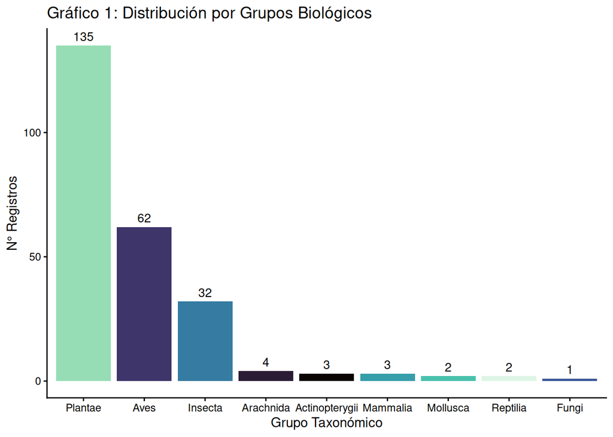

Tabla 1: Especies con mayor representatividad

| Especie | Grupo | N° Registros |
| --- | --- | --- |
| Cygnus melancoryphus | Aves | 9 |
| Fulica rufifrons | Aves | 9 |
| Quillaja saponaria | Plantae | 9 |
| Peumus boldus | Plantae | 7 |
| Podiceps major | Aves | 7 |

Nota: Fuente: BioCore API e iNaturalist (2025).

Identificadas las especies predominantes (ver Tabla 1), el siguiente análisis permite espacializar dicha riqueza. A continuación, se presenta la distribución de los hallazgos mediante una malla de alta resolución, facilitando la detección de núcleos de biodiversidad que requieren medidas de protección diferenciadas.

### B) Mapa de Riqueza por hexágonos

Mapa 2: Densidad de especies por cuadrantes

[interactive chart not shown]

Nota: Distribución espacial basada en la malla de alta resolución BioCore.

Esta representación mediante binning hexagonal permite normalizar la densidad de registros, eliminando sesgos de muestreo y revelando con precisión los sectores de mayor valor ecológico. Este mapa constituye la base para el diseño de perímetros de exclusión y planes de rescate y relocalización, asegurando la integridad de los hábitats críticos identificados.

### C) Visor de Densidad de Biodiversidad y Análisis de Impacto

Este visor integra el análisis de densidad nuclear (Heatmap) para localizar con precisión las zonas de mayor presión biológica. El cruce espacial entre la densidad de hallazgos y el área de intervención permite priorizar acciones de salvaguarda en los sectores donde la sensibilidad ecosistémica es crítica.

Mapa 3: Núcleos de biodiversidad detectados

[interactive chart not shown]

Fuente: Elaboración propia para BioCore mediante algoritmos de densidad Kernel.

Análisis de Resultados: El visor interactivo permite observar cómo la densidad de especies (representada por el mapa de calor) interactúa con el área de intervención proyectada.

Identificación de Riesgos: El uso de este tipo de herramientas permite a los titulares de proyectos prever impactos antes de la ejecución de obras.

Calidad de Datos: Los registros visualizados han sido procesados para asegurar precisión geográfica, minimizando errores de mapeo que podrían alterar la evaluación de impacto ambiental.

## 3. Detalle de Afectación en el Área de Influencia Directa

A continuación, se listan las especies detectadas mediante el cruce espacial de datos iNaturalist con el polígono de intervención. Esta tabla es una herramienta clave para la Gestión Ambiental y el cumplimiento de la Normativa SMA.

Gráfico 2: Análisis de Proximidad a Factores de Amenaza.

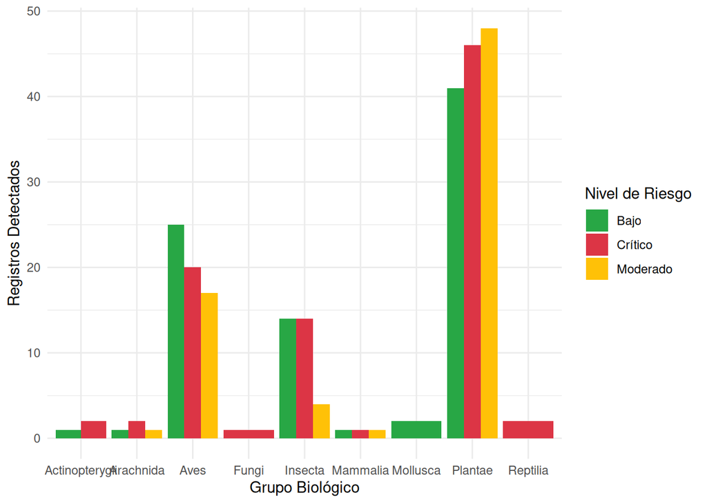

Análisis de Resultados (Gráfico Superior):

La gráfica anterior identifica los niveles de riesgo detectados en la zona de la Laguna Señoraza. Esta visualización permite identificar qué grupos taxonómicos requieren mayor atención debido a su cercanía a áreas de posible perturbación antrópica.

Tabla 2: Especies Protegidas y Prioridad de Conservación en la Laguna.

| Nombre Común | Nombre Científico | Categoría (SBAP/RCE) |
| --- | --- | --- |
| **Cisne de cuello negro** | Cygnus melancoryphus | Vulnerable (⚠️) |
| **Carpa** | Cyprinus carpio | Preocupación Menor (LC) |
| **Tagua chica** | Fulica leucoptera | Preocupación Menor (LC) |
| **Tagüita** | Porphyriops melanops | Preocupación Menor (LC) |
| **Trile** | Agelasticus thilius | Preocupación Menor (LC) |
| **Sietecolores** | Tachuris rubrigastra | Preocupación Menor |
| **Tagua** | Fulica armillata | Preocupación Menor (LC) |
| **Tagua de frente roja** | Fulica rufifrons | Preocupación Menor (LC) |
| **Picurio** | Podilymbus podiceps | Preocupación Menor (LC) |
| **Huala** | Podiceps major | Preocupación Menor (LC) |

En esta tabla se resaltan en negrita todas las especies dentro del área de impacto. Aquellas que además poseen un Estado de Conservación relevante se muestran en color naranja (⚠️) para alertar al evaluador ambiental.

## 4. Conclusiones y Valor Agregado

*Este informe constituye un documento preliminar de diagnóstico biológico.*

[figure not shown]

**Loreto Norma Campos Carrasco**

*Biología | University of Concepción (UdeC)*

Especialista en Consultoría Ambiental y Biodiversidad

[Sitio Web BioCore](https://consultorabiocore.github.io) | [LinkedIn](https://www.linkedin.com/in/loretocamp) | Contacto Directo

**BioCore: Ciencia de Datos para la Gestión Ambiental**